# Project: Investigate a Dataset

## Do patients in Brazil in 2016 show up for their medical appointments?

## If they don't, what are the key factors that explain it?

- Introduction
- Data Wrangling
- Exploratory Data Analysis
- Conclusions

## Introduction

### What are the important factors in order to predict if a patient will show up for their scheduled appointment?

> Welcome to the Brazil_noshowappointments_2016 Dataset project! I'm Jaime Rado, and in this project you will find my insights with regards to a dataset collected in 2016 over 100k medical appointments in Brazil. It is focused on the question of whether or not patients show up for their appointment.

> A number of characteristics about the patient are included in each row.
> - ‘ScheduledDay’ tells us on what day the patient set up their appointment.
> - ‘Neighborhood’ indicates the location of the hospital.
> - ‘Scholarship’ indicates whether or not the patient is enrolled in Brazilian welfare program Bolsa Família.

```python
import numpy as np
import pandas as pd
import matplotlib.pyplot as plt
import seaborn as sns
% matplotlib inline
```

## Data Wrangling

> In this section of the report, I will load in the data, check for cleanliness, and then trim and clean the dataset for analysis.

### General Properties

```python
df = pd.read_csv('Brazil_noshowappointments_2016.csv')
print(df.shape)
df.head()
```

```
(110527, 14)
```

|  | PatientId | AppointmentID | Gender | ScheduledDay | AppointmentDay | Age | Neighbourhood | Scholarship | Hipertension | Diabetes | Alcoholism | Handcap | SMS_received | No-show |
| --- | --- | --- | --- | --- | --- | --- | --- | --- | --- | --- | --- | --- | --- | --- |
| 0 | 2.987250e+13 | 5642903 | F | 2016-04-29T18:38:08Z | 2016-04-29T00:00:00Z | 62 | JARDIM DA PENHA | 0 | 1 | 0 | 0 | 0 | 0 | No |
| 1 | 5.589978e+14 | 5642503 | M | 2016-04-29T16:08:27Z | 2016-04-29T00:00:00Z | 56 | JARDIM DA PENHA | 0 | 0 | 0 | 0 | 0 | 0 | No |
| 2 | 4.262962e+12 | 5642549 | F | 2016-04-29T16:19:04Z | 2016-04-29T00:00:00Z | 62 | MATA DA PRAIA | 0 | 0 | 0 | 0 | 0 | 0 | No |
| 3 | 8.679512e+11 | 5642828 | F | 2016-04-29T17:29:31Z | 2016-04-29T00:00:00Z | 8 | PONTAL DE CAMBURI | 0 | 0 | 0 | 0 | 0 | 0 | No |
| 4 | 8.841186e+12 | 5642494 | F | 2016-04-29T16:07:23Z | 2016-04-29T00:00:00Z | 56 | JARDIM DA PENHA | 0 | 1 | 1 | 0 | 0 | 0 | No |

```python
# First I want to familiarize with the dataset. I will take a look at info, unique values, duplicates and describe functions.
df.info()
```

```
<class 'pandas.core.frame.DataFrame'>
RangeIndex: 110527 entries, 0 to 110526
Data columns (total 14 columns):
PatientId         110527 non-null float64
AppointmentID     110527 non-null int64
Gender            110527 non-null object
ScheduledDay      110527 non-null object
AppointmentDay    110527 non-null object
Age               110527 non-null int64
Neighbourhood     110527 non-null object
Scholarship       110527 non-null int64
Hipertension      110527 non-null int64
Diabetes          110527 non-null int64
Alcoholism        110527 non-null int64
Handcap           110527 non-null int64
SMS_received      110527 non-null int64
No-show           110527 non-null object
dtypes: float64(1), int64(8), object(5)
memory usage: 11.8+ MB
```

```python
df.nunique()
```

```
PatientId          62299
AppointmentID     110527
Gender                 2
ScheduledDay      103549
AppointmentDay        27
Age                  104
Neighbourhood         81
Scholarship            2
Hipertension           2
Diabetes               2
Alcoholism             2
Handcap                5
SMS_received           2
No-show                2
dtype: int64
```

```python
df.duplicated().sum()
```

```
0
```

```python
df.describe()
```

|  | PatientId | AppointmentID | Age | Scholarship | Hipertension | Diabetes | Alcoholism | Handcap | SMS_received |
| --- | --- | --- | --- | --- | --- | --- | --- | --- | --- |
| count | 1.105270e+05 | 1.105270e+05 | 110527.000000 | 110527.000000 | 110527.000000 | 110527.000000 | 110527.000000 | 110527.000000 | 110527.000000 |
| mean | 1.474963e+14 | 5.675305e+06 | 37.088874 | 0.098266 | 0.197246 | 0.071865 | 0.030400 | 0.022248 | 0.321026 |
| std | 2.560949e+14 | 7.129575e+04 | 23.110205 | 0.297675 | 0.397921 | 0.258265 | 0.171686 | 0.161543 | 0.466873 |
| min | 3.921784e+04 | 5.030230e+06 | -1.000000 | 0.000000 | 0.000000 | 0.000000 | 0.000000 | 0.000000 | 0.000000 |
| 25% | 4.172614e+12 | 5.640286e+06 | 18.000000 | 0.000000 | 0.000000 | 0.000000 | 0.000000 | 0.000000 | 0.000000 |
| 50% | 3.173184e+13 | 5.680573e+06 | 37.000000 | 0.000000 | 0.000000 | 0.000000 | 0.000000 | 0.000000 | 0.000000 |
| 75% | 9.439172e+13 | 5.725524e+06 | 55.000000 | 0.000000 | 0.000000 | 0.000000 | 0.000000 | 0.000000 | 1.000000 |
| max | 9.999816e+14 | 5.790484e+06 | 115.000000 | 1.000000 | 1.000000 | 1.000000 | 1.000000 | 4.000000 | 1.000000 |

> In order to assess the data, what I see so far is:
> - There are no empty cells.
> - Apparently, there are no duplicates. However, 'PatientId' has only 62299 values. That can anyway mean that there are in fact duplicates.
> - Minimum Age is (-1). I should take a look at how many they are and try to understand it.
> - I want to lower case all column's titles and change slightly their names.
> - I want to put the 'No-show' column all the way around because it might lead to errors and misunderstandings for the readers.

### Data Cleaning

```python
# Lower case all column's titles

df.rename(columns=lambda x: x.strip().lower(), inplace=True)
df.head(1)
```

|  | patientid | appointmentid | gender | scheduledday | appointmentday | age | neighbourhood | scholarship | hipertension | diabetes | alcoholism | handcap | sms_received | no-show |
| --- | --- | --- | --- | --- | --- | --- | --- | --- | --- | --- | --- | --- | --- | --- |
| 0 | 2.987250e+13 | 5642903 | F | 2016-04-29T18:38:08Z | 2016-04-29T00:00:00Z | 62 | JARDIM DA PENHA | 0 | 1 | 0 | 0 | 0 | 0 | No |

```python
# Change column's names

df.rename(columns={'patientid': 'patient_id', 'appointmentid': 'appointment_id', 'scheduledday': 'scheduled_day', 'appointmentday': 'appointment_day','no-show': 'show'}, inplace=True)
df.head(1)
```

|  | patient_id | appointment_id | gender | scheduled_day | appointment_day | age | neighbourhood | scholarship | hipertension | diabetes | alcoholism | handcap | sms_received | show |
| --- | --- | --- | --- | --- | --- | --- | --- | --- | --- | --- | --- | --- | --- | --- |
| 0 | 2.987250e+13 | 5642903 | F | 2016-04-29T18:38:08Z | 2016-04-29T00:00:00Z | 62 | JARDIM DA PENHA | 0 | 1 | 0 | 0 | 0 | 0 | No |

```python
# I put all the way around the field 'No-show'. Now it is called 'show' and it is going to have integer values
# 0 for NO-showups and 1 for YES-showups

df['show'] = df['show'].replace('No', 1)
df['show'] = df['show'].replace('Yes', 0)
```

```python
df.head()
```

|  | patient_id | appointment_id | gender | scheduled_day | appointment_day | age | neighbourhood | scholarship | hipertension | diabetes | alcoholism | handcap | sms_received | show |
| --- | --- | --- | --- | --- | --- | --- | --- | --- | --- | --- | --- | --- | --- | --- |
| 0 | 2.987250e+13 | 5642903 | F | 2016-04-29T18:38:08Z | 2016-04-29T00:00:00Z | 62 | JARDIM DA PENHA | 0 | 1 | 0 | 0 | 0 | 0 | 1 |
| 1 | 5.589978e+14 | 5642503 | M | 2016-04-29T16:08:27Z | 2016-04-29T00:00:00Z | 56 | JARDIM DA PENHA | 0 | 0 | 0 | 0 | 0 | 0 | 1 |
| 2 | 4.262962e+12 | 5642549 | F | 2016-04-29T16:19:04Z | 2016-04-29T00:00:00Z | 62 | MATA DA PRAIA | 0 | 0 | 0 | 0 | 0 | 0 | 1 |
| 3 | 8.679512e+11 | 5642828 | F | 2016-04-29T17:29:31Z | 2016-04-29T00:00:00Z | 8 | PONTAL DE CAMBURI | 0 | 0 | 0 | 0 | 0 | 0 | 1 |
| 4 | 8.841186e+12 | 5642494 | F | 2016-04-29T16:07:23Z | 2016-04-29T00:00:00Z | 56 | JARDIM DA PENHA | 0 | 1 | 1 | 0 | 0 | 0 | 1 |

```python
df['show'] = df['show'].astype(int)
```

```python
df.dtypes
```

```
patient_id         float64
appointment_id       int64
gender              object
scheduled_day       object
appointment_day     object
age                  int64
neighbourhood       object
scholarship          int64
hipertension         int64
diabetes             int64
alcoholism           int64
handcap              int64
sms_received         int64
show                 int64
dtype: object
```

```python
# Let's take a look at the negative 'age' values
df.age.value_counts()
```

```
 0      3539
 1      2273
 52     1746
 49     1652
 53     1651
 56     1635
 38     1629
 59     1624
 2      1618
 50     1613
 57     1603
 36     1580
 51     1567
 19     1545
 39     1536
```

[output cut: 47 more lines]

```python
# How many rows are there?
df[df['age'] == df['age'].min()]
```

|  | patient_id | appointment_id | gender | scheduled_day | appointment_day | age | neighbourhood | scholarship | hipertension | diabetes | alcoholism | handcap | sms_received | show |
| --- | --- | --- | --- | --- | --- | --- | --- | --- | --- | --- | --- | --- | --- | --- |
| 99832 | 4.659432e+14 | 5775010 | F | 2016-06-06T08:58:13Z | 2016-06-06T00:00:00Z | -1 | ROMÃO | 0 | 0 | 0 | 0 | 0 | 0 | 1 |

```python
# There is only one row for a negative age and could be because it is a pregnant woman. I'm not going to delete it.
```

```python
# 'appointment_id' field will mislead my investigation on 'gender', 'age' or 'neighbourhood' comparison because it allows
# a person to appear more than once, and this is not good

# If I convert 'scheduled_day' and 'appointment_day' to date format I might be able to substract one another and get insights
# about the appointment's drop with much time in advance

# I should see how 'sms_received' and 'show' relate.
```

## Questions

### Question 1

> How many appointments are succesful?

### Question 2

> Is there a correlation between the fact of having received a sms before the scheduled day and eventually show up?

### Question 3

> Is there a correlation between the fact of having scheduled much time in advance and showing up?

### Question 4

> Is there a difference in the success of the appointment because of gender or age?

## Exploratory Data Analysis

### Research Question 1 (How many appointments were successful?)

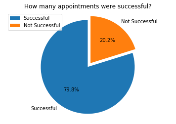

```python
# Let's see how many appointments have been successful

pie_yes = (len(df[df['show']==1]))
pie_no = (len(df[df['show']==0]))

x_labels = ['Successful', 'Not Successful']
y = [pie_yes, pie_no]
explode = (0.1, 0)
plt.pie(y, labels=x_labels, explode=explode, autopct='%1.1f%%', startangle=90)
plt.legend(labels=x_labels)
plt.axis('equal')
plt.title('How many appointments were successful?');
```

### Insight 1: 80% of the appointments were succesful!

#### **What happen with the other 20%?** Let's answer questions 2, 3 and 4

### Research Question 2 (Is there a correlation between sms_received and show=yes?)

```python
# Let's do some queries

# Samples NO sms_received
no_sms = df.query('sms_received == 0')

# Samples YES sms_received
yes_sms = df.query('sms_received == 1')

# Let's make sure I have all data
num_samples = df.shape[0]
num_samples == no_sms['show'].count() + yes_sms['show'].count()
```

```
True
```

```python
# Now I calculate the total number of people who did not receive a SMS

total_no_sms = no_sms['show'].count()
total_no_sms
```

```
75045
```

```python
# Amount of people who did receive a SMS

total_yes_sms = yes_sms['show'].count()
total_yes_sms
```

```
35482
```

```python
# Let's do another query to see how many people show up for each total

show_no_sms = no_sms.query('show == 1')
show_yes_sms = yes_sms.query('show == 1')
```

```python
# The total number of people who **showed** and **did not** receive a SMS

total_show_no_sms = show_no_sms['show'].count()
total_show_no_sms
```

```
62510
```

```python
# Total number of people who **showed** and **did** receive a SMS

total_show_yes_sms = show_yes_sms['show'].count()
total_show_yes_sms
```

```
25698
```

```python
# Now that I have both totals, I can calculate proportions for each to see the correlation between receiving a SMS
# and going to the appointment, having first removed the total amounts. Proportions work better for us here!

prop_no_sms = total_show_no_sms/total_no_sms
prop_yes_sms = total_show_yes_sms/total_yes_sms
prop_no_sms, prop_yes_sms
```

```
(0.83296688653474582, 0.72425455160363006)
```

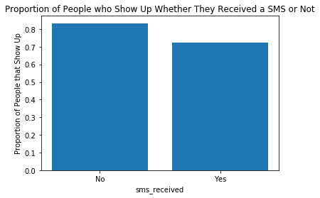

```python
# Let's visualize it

plt.bar(["No", "Yes"], [prop_no_sms, prop_yes_sms])
plt.title("Proportion of People who Show Up Whether They Received a SMS or Not")
plt.xlabel("sms_received")
plt.ylabel("Proportion of People that Show Up");
```

### Research Question 3 (Is there a correlation between the fact of having scheduled much time in advance and not showing up?)

```python
# First, I need to convert some strings to datetime

df.info()
```

```
<class 'pandas.core.frame.DataFrame'>
RangeIndex: 110527 entries, 0 to 110526
Data columns (total 14 columns):
patient_id         110527 non-null float64
appointment_id     110527 non-null int64
gender             110527 non-null object
scheduled_day      110527 non-null object
appointment_day    110527 non-null object
age                110527 non-null int64
neighbourhood      110527 non-null object
scholarship        110527 non-null int64
hipertension       110527 non-null int64
diabetes           110527 non-null int64
alcoholism         110527 non-null int64
handcap            110527 non-null int64
sms_received       110527 non-null int64
show               110527 non-null int64
dtypes: float64(1), int64(9), object(4)
memory usage: 11.8+ MB
```

```python
# The difference between 'appointment_day' and 'scheduled_day' will give me the time difference

df['scheduled_day'] = pd.to_datetime(df['scheduled_day'])
df['appointment_day'] = pd.to_datetime(df['appointment_day'])
df.info()
```

```
<class 'pandas.core.frame.DataFrame'>
RangeIndex: 110527 entries, 0 to 110526
Data columns (total 14 columns):
patient_id         110527 non-null float64
appointment_id     110527 non-null int64
gender             110527 non-null object
scheduled_day      110527 non-null datetime64[ns]
appointment_day    110527 non-null datetime64[ns]
age                110527 non-null int64
neighbourhood      110527 non-null object
scholarship        110527 non-null int64
hipertension       110527 non-null int64
diabetes           110527 non-null int64
alcoholism         110527 non-null int64
handcap            110527 non-null int64
sms_received       110527 non-null int64
show               110527 non-null int64
dtypes: datetime64[ns](2), float64(1), int64(9), object(2)
memory usage: 11.8+ MB
```

```python
# But I only want the date, as time it isn't necessary for my investigation

df['scheduled_day'] = df['scheduled_day'].dt.date
df['appointment_day'] = df['appointment_day'].dt.date
```

```python
df.head()
```

|  | patient_id | appointment_id | gender | scheduled_day | appointment_day | age | neighbourhood | scholarship | hipertension | diabetes | alcoholism | handcap | sms_received | show |
| --- | --- | --- | --- | --- | --- | --- | --- | --- | --- | --- | --- | --- | --- | --- |
| 0 | 2.987250e+13 | 5642903 | F | 2016-04-29 | 2016-04-29 | 62 | JARDIM DA PENHA | 0 | 1 | 0 | 0 | 0 | 0 | 1 |
| 1 | 5.589978e+14 | 5642503 | M | 2016-04-29 | 2016-04-29 | 56 | JARDIM DA PENHA | 0 | 0 | 0 | 0 | 0 | 0 | 1 |
| 2 | 4.262962e+12 | 5642549 | F | 2016-04-29 | 2016-04-29 | 62 | MATA DA PRAIA | 0 | 0 | 0 | 0 | 0 | 0 | 1 |
| 3 | 8.679512e+11 | 5642828 | F | 2016-04-29 | 2016-04-29 | 8 | PONTAL DE CAMBURI | 0 | 0 | 0 | 0 | 0 | 0 | 1 |
| 4 | 8.841186e+12 | 5642494 | F | 2016-04-29 | 2016-04-29 | 56 | JARDIM DA PENHA | 0 | 1 | 1 | 0 | 0 | 0 | 1 |

```python
# Then, I create a new column with the difference between both fields

df['difference_day'] = df['appointment_day'] - df['scheduled_day']
df.info()
```

```
<class 'pandas.core.frame.DataFrame'>
RangeIndex: 110527 entries, 0 to 110526
Data columns (total 15 columns):
patient_id         110527 non-null float64
appointment_id     110527 non-null int64
gender             110527 non-null object
scheduled_day      110527 non-null object
appointment_day    110527 non-null object
age                110527 non-null int64
neighbourhood      110527 non-null object
scholarship        110527 non-null int64
hipertension       110527 non-null int64
diabetes           110527 non-null int64
alcoholism         110527 non-null int64
handcap            110527 non-null int64
sms_received       110527 non-null int64
show               110527 non-null int64
difference_day     110527 non-null timedelta64[ns]
dtypes: float64(1), int64(9), object(4), timedelta64[ns](1)
memory usage: 12.6+ MB
```

```python
# Let's make sure it has worked out

df.difference_day.describe()
```

```
count                     110527
mean     10 days 04:24:31.828602
std      15 days 06:07:11.673762
min            -6 days +00:00:00
25%              0 days 00:00:00
50%              4 days 00:00:00
75%             15 days 00:00:00
max            179 days 00:00:00
Name: difference_day, dtype: object
```

```python
# I want to extract only the number of days: get the integer and remove everything else in the row

df['difference_day'] = df['difference_day'].astype(str)
```

```python
df['difference_day'] = df['difference_day'].str.extract('(\d+)').astype(int)
```

```python
df.info()
```

```
<class 'pandas.core.frame.DataFrame'>
RangeIndex: 110527 entries, 0 to 110526
Data columns (total 15 columns):
patient_id         110527 non-null float64
appointment_id     110527 non-null int64
gender             110527 non-null object
scheduled_day      110527 non-null object
appointment_day    110527 non-null object
age                110527 non-null int64
neighbourhood      110527 non-null object
scholarship        110527 non-null int64
hipertension       110527 non-null int64
diabetes           110527 non-null int64
alcoholism         110527 non-null int64
handcap            110527 non-null int64
sms_received       110527 non-null int64
show               110527 non-null int64
difference_day     110527 non-null int64
dtypes: float64(1), int64(10), object(4)
memory usage: 12.6+ MB
```

```python
df.head()
```

|  | patient_id | appointment_id | gender | scheduled_day | appointment_day | age | neighbourhood | scholarship | hipertension | diabetes | alcoholism | handcap | sms_received | show | difference_day |
| --- | --- | --- | --- | --- | --- | --- | --- | --- | --- | --- | --- | --- | --- | --- | --- |
| 0 | 2.987250e+13 | 5642903 | F | 2016-04-29 | 2016-04-29 | 62 | JARDIM DA PENHA | 0 | 1 | 0 | 0 | 0 | 0 | 1 | 0 |
| 1 | 5.589978e+14 | 5642503 | M | 2016-04-29 | 2016-04-29 | 56 | JARDIM DA PENHA | 0 | 0 | 0 | 0 | 0 | 0 | 1 | 0 |
| 2 | 4.262962e+12 | 5642549 | F | 2016-04-29 | 2016-04-29 | 62 | MATA DA PRAIA | 0 | 0 | 0 | 0 | 0 | 0 | 1 | 0 |
| 3 | 8.679512e+11 | 5642828 | F | 2016-04-29 | 2016-04-29 | 8 | PONTAL DE CAMBURI | 0 | 0 | 0 | 0 | 0 | 0 | 1 | 0 |
| 4 | 8.841186e+12 | 5642494 | F | 2016-04-29 | 2016-04-29 | 56 | JARDIM DA PENHA | 0 | 1 | 1 | 0 | 0 | 0 | 1 | 0 |

```python
# Now, I'm ready to visualize the results

visual_difference_day = df.groupby('show').difference_day.mean()
visual_difference_day
```

```
show
0    15.832385
1     8.754659
Name: difference_day, dtype: float64
```

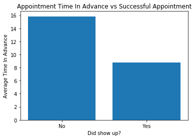

```python
locations = [1, 2]
heights = visual_difference_day
labels = ['No', 'Yes']
plt.bar(locations, heights, tick_label=labels)
plt.title('Appointment Time In Advance vs Successful Appointment')
plt.xlabel('Did show up?')
plt.ylabel('Average Time In Advance');
```

### Insight 3: There is a correlation between scheduling time and successful appointment. The less time between the scheduled date and appointment date, the higher the probability that the patient shows up.

### Research Question 4 (Do gender or age influence an appointment's success?)

```python
# Let's look at gender

df.head()
```

|  | patient_id | appointment_id | gender | scheduled_day | appointment_day | age | neighbourhood | scholarship | hipertension | diabetes | alcoholism | handcap | sms_received | show | difference_day |
| --- | --- | --- | --- | --- | --- | --- | --- | --- | --- | --- | --- | --- | --- | --- | --- |
| 0 | 2.987250e+13 | 5642903 | F | 2016-04-29 | 2016-04-29 | 62 | JARDIM DA PENHA | 0 | 1 | 0 | 0 | 0 | 0 | 1 | 0 |
| 1 | 5.589978e+14 | 5642503 | M | 2016-04-29 | 2016-04-29 | 56 | JARDIM DA PENHA | 0 | 0 | 0 | 0 | 0 | 0 | 1 | 0 |
| 2 | 4.262962e+12 | 5642549 | F | 2016-04-29 | 2016-04-29 | 62 | MATA DA PRAIA | 0 | 0 | 0 | 0 | 0 | 0 | 1 | 0 |
| 3 | 8.679512e+11 | 5642828 | F | 2016-04-29 | 2016-04-29 | 8 | PONTAL DE CAMBURI | 0 | 0 | 0 | 0 | 0 | 0 | 1 | 0 |
| 4 | 8.841186e+12 | 5642494 | F | 2016-04-29 | 2016-04-29 | 56 | JARDIM DA PENHA | 0 | 1 | 1 | 0 | 0 | 0 | 1 | 0 |

```python
df.groupby(['gender', 'patient_id']).mean()
```

[output not shown]

62299 rows × 10 columns

```python
# Let's visualize the mean 'show' per 'gender'

female = df.query('gender == "F"')
male = df.query('gender == "M"')

female_show = female['show'].mean()
male_show = male['show'].mean()
```

```python
# Results

female_show, male_show
```

```
(0.79685412026726055, 0.80032052110528085)
```

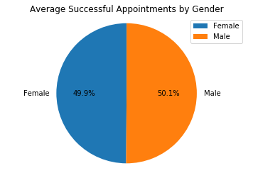

```python
# Let's visualize the results

x_labels = ['Female', 'Male']
y = [female_show, male_show]
plt.pie(y, labels=x_labels, autopct='%1.1f%%', startangle=90)
plt.legend(labels=x_labels)
plt.axis('equal')
plt.title('Average Successful Appointments by Gender');
```

### Insight 4.1: There is no difference between Men and Women

```python
# Let's now look at age. Does it make a difference?

df.age.describe()
```

```
count    110527.000000
mean         37.088874
std          23.110205
min          -1.000000
25%          18.000000
50%          37.000000
75%          55.000000
max         115.000000
Name: age, dtype: float64
```

```python
# I will create a new column with groups of ages to have a clear histogram

bin_edges = [-1.00, 18.00, 37.00, 55.00, 115.00]
```

```python
bin_names = ['0-18', '18-37', '37-55', '55-115']
```

```python
df['ages_groups'] = pd.cut(df['age'], bin_edges, labels=bin_names)
df.head()
```

|  | patient_id | appointment_id | gender | scheduled_day | appointment_day | age | neighbourhood | scholarship | hipertension | diabetes | alcoholism | handcap | sms_received | show | difference_day | ages_groups |
| --- | --- | --- | --- | --- | --- | --- | --- | --- | --- | --- | --- | --- | --- | --- | --- | --- |
| 0 | 2.987250e+13 | 5642903 | F | 2016-04-29 | 2016-04-29 | 62 | JARDIM DA PENHA | 0 | 1 | 0 | 0 | 0 | 0 | 1 | 0 | 55-115 |
| 1 | 5.589978e+14 | 5642503 | M | 2016-04-29 | 2016-04-29 | 56 | JARDIM DA PENHA | 0 | 0 | 0 | 0 | 0 | 0 | 1 | 0 | 55-115 |
| 2 | 4.262962e+12 | 5642549 | F | 2016-04-29 | 2016-04-29 | 62 | MATA DA PRAIA | 0 | 0 | 0 | 0 | 0 | 0 | 1 | 0 | 55-115 |
| 3 | 8.679512e+11 | 5642828 | F | 2016-04-29 | 2016-04-29 | 8 | PONTAL DE CAMBURI | 0 | 0 | 0 | 0 | 0 | 0 | 1 | 0 | 0-18 |
| 4 | 8.841186e+12 | 5642494 | F | 2016-04-29 | 2016-04-29 | 56 | JARDIM DA PENHA | 0 | 1 | 1 | 0 | 0 | 0 | 1 | 0 | 55-115 |

```python
# Now I'm ready to visualize it

visual_age = df.groupby('ages_groups').mean().show
visual_age
```

```
ages_groups
0-18      0.780122
18-37     0.764624
37-55     0.804690
55-115    0.843550
Name: show, dtype: float64
```

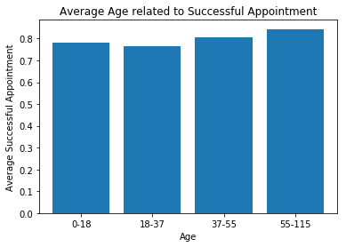

```python
locations = [1, 2, 3, 4]
heights = visual_age
labels = ['0-18', '18-37', '37-55', '55-115']
plt.bar(locations, heights, tick_label=labels)
plt.title('Average Age related to Successful Appointment')
plt.xlabel('Age')
plt.ylabel('Average Successful Appointment');
```

### Insight 4.2: We can see a slight trend with regards to patient's age. There is hence a correlation between the age of the patient and the guarantee that he/she will show up.

## Conclusions

> 80% of all appointments in Brazil in 2016 were successful.

#### Among the 20% that weren't, these are the key factors to know what happened

> The fact of having received a SMS before the appointment doesn't make the appointment more likely to be successful

> The less time between the scheduled date and appointment date, the higher the probability that the patient shows up.

> There is no correlation between success likelihood of an appointment and 'gender'

## Some Limitations

> The field 'appointment_id' creates a new row every time a patient asks for one appointment, which is necessary to compare the success of the overall appointments. But it can limit my investigations regarding categorical data such as gender and age. As a patient can appear more than once and hence leads to a biased outcome.

> There is a minimum age of (-1) and it is not specified at any place what it means. I made hence the assumption that it was a pregnant woman (as the gender for that row was female).

> In some cases appointment_day is earlier than scheduled_day, which should be impossible. These might be due to a rescheduled day that hasn't been updated in the system.

> The No-show column is not intuitive at all. It could lead to misunderstandings if not changed.

```python
from subprocess import call
call(['python', '-m', 'nbconvert', 'Investigate_a_Dataset.ipynb'])
```

```
0
```